# Many Models

David Gerard

2022-11-16

# Learning Objectives

- Use a list-column to run many models at once.
- Chapter 25 from [RDS](https://r4ds.had.co.nz/).

# Motivation

- The gapminder data

  ```r
  library(tidyverse)
  library(broom)
  library(gapminder)
  data("gapminder")
  glimpse(gapminder)
  ```

  ```
  ## Rows: 1,704
  ## Columns: 6
  ## $ country   <fct> "Afghanistan", "Afghanistan", "Afghanistan", "Afghanistan", …
  ## $ continent <fct> Asia, Asia, Asia, Asia, Asia, Asia, Asia, Asia, Asia, Asia, …
  ## $ year      <int> 1952, 1957, 1962, 1967, 1972, 1977, 1982, 1987, 1992, 1997, …
  ## $ lifeExp   <dbl> 28.80, 30.33, 32.00, 34.02, 36.09, 38.44, 39.85, 40.82, 41.6…
  ## $ pop       <int> 8425333, 9240934, 10267083, 11537966, 13079460, 14880372, 12…
  ## $ gdpPercap <dbl> 779.4, 820.9, 853.1, 836.2, 740.0, 786.1, 978.0, 852.4, 649.…
  ```

- Suppose we want to look at how life expectancy has changed over time in each country:

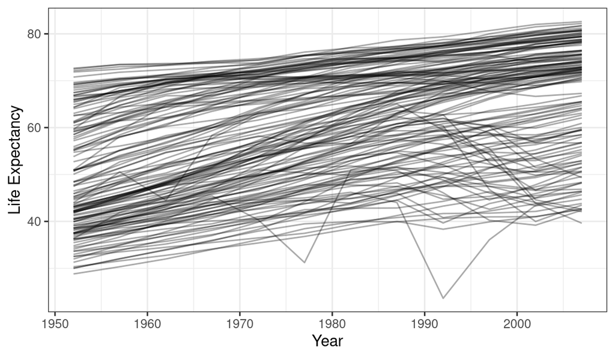

  ```r
  gapminder %>%
    ggplot(aes(x = year, y = lifeExp, group = country)) +
    geom_line(alpha = 1/3) +
    xlab("Year") +
    ylab("Life Expectancy")
  ```

- General trend is going up. But there are some countries where this doesn’t happen. How do we quantify the trend? We can do this with one country using a linear model:

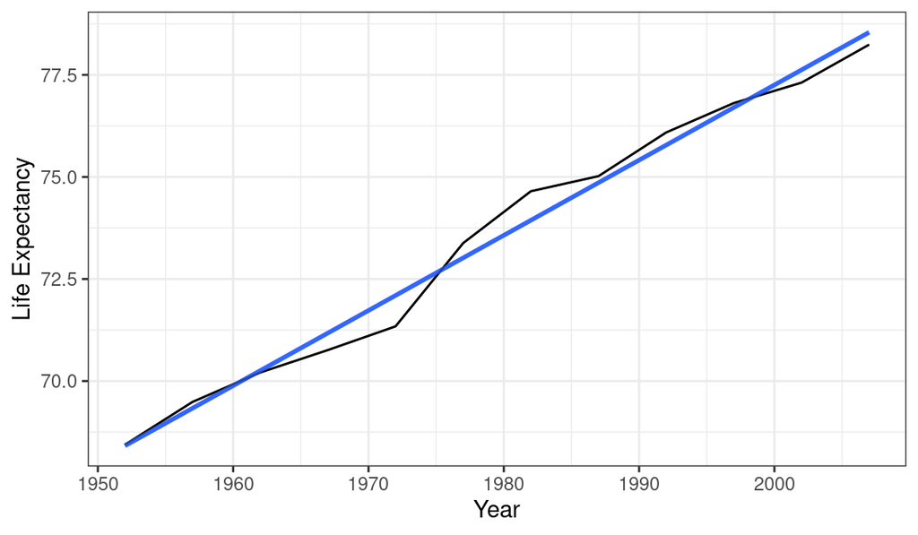

  ```r
  gapminder %>%
    filter(country == "United States") ->
    usdf

  ggplot(usdf, aes(x = year, y = lifeExp)) +
    geom_line() +
    geom_smooth(method = "lm", se = FALSE) +
    geom_line(alpha = 1/3) +
    xlab("Year") +
    ylab("Life Expectancy")
  ```

  ```r
  us_lmout <- lm(lifeExp ~ year, data = usdf)
  tidy_uslm <- tidy(us_lmout)
  tidy_uslm
  ```

  ```
  ## # A tibble: 2 × 5
  ##   term        estimate std.error statistic  p.value
  ##   <chr>          <dbl>     <dbl>     <dbl>    <dbl>
  ## 1 (Intercept) -291.     13.8         -21.1 1.25e- 9
  ## 2 year           0.184   0.00696      26.5 1.37e-10
  ```

- So each year, the US has been increasing its life expectancy by 0.1842 years.
- How can we get these coefficient estimates for each country?
- For the exercises in this lesson plan, you should log the `pop` variable now:

  ```r
  gapminder %>%
    mutate(logpop = log2(pop)) ->
    gapminder
  ```

- **Exercise**: Create a line plot for year vs log-population for each country.
- **Exercise**: For China, fit a linear model for log-population on year. Make sure the assumptions of the linear model are fulfilled. Interpret the coefficients

# Nest

- The `nest()` function from the tidyr package will turn a *grouped* data frame into a data frame where each group is a row. All of the observations are placed in the `data` variable as a data frame. Let’s look at an example.

  ```r
  gapminder %>%
    group_by(country, continent) %>%
    nest() ->
    nested_gap_df

  nested_gap_df
  ```

  ```
  ## # A tibble: 142 × 3
  ## # Groups:   country, continent [142]
  ##    country     continent data
  ##    <fct>       <fct>     <list>
  ##  1 Afghanistan Asia      <tibble [12 × 5]>
  ##  2 Albania     Europe    <tibble [12 × 5]>
  ##  3 Algeria     Africa    <tibble [12 × 5]>
  ##  4 Angola      Africa    <tibble [12 × 5]>
  ##  5 Argentina   Americas  <tibble [12 × 5]>
  ##  6 Australia   Oceania   <tibble [12 × 5]>
  ##  7 Austria     Europe    <tibble [12 × 5]>
  ##  8 Bahrain     Asia      <tibble [12 × 5]>
  ##  9 Bangladesh  Asia      <tibble [12 × 5]>
  ## 10 Belgium     Europe    <tibble [12 × 5]>
  ## # … with 132 more rows
  ```

- The `data` variable is a list. Each element is a data frame that contains all of the observations in the group we created by `country`.
- Observations from Afghanistan

  ```r
  nested_gap_df$data[[1]]
  ```

  ```
  ## # A tibble: 12 × 5
  ##     year lifeExp      pop gdpPercap logpop
  ##    <int>   <dbl>    <int>     <dbl>  <dbl>
  ##  1  1952    28.8  8425333      779.   23.0
  ##  2  1957    30.3  9240934      821.   23.1
  ##  3  1962    32.0 10267083      853.   23.3
  ##  4  1967    34.0 11537966      836.   23.5
  ##  5  1972    36.1 13079460      740.   23.6
  ##  6  1977    38.4 14880372      786.   23.8
  ##  7  1982    39.9 12881816      978.   23.6
  ##  8  1987    40.8 13867957      852.   23.7
  ##  9  1992    41.7 16317921      649.   24.0
  ## 10  1997    41.8 22227415      635.   24.4
  ## 11  2002    42.1 25268405      727.   24.6
  ## 12  2007    43.8 31889923      975.   24.9
  ```

- Observations from Albania

  ```r
  nested_gap_df$data[[2]]
  ```

  ```
  ## # A tibble: 12 × 5
  ##     year lifeExp     pop gdpPercap logpop
  ##    <int>   <dbl>   <int>     <dbl>  <dbl>
  ##  1  1952    55.2 1282697     1601.   20.3
  ##  2  1957    59.3 1476505     1942.   20.5
  ##  3  1962    64.8 1728137     2313.   20.7
  ##  4  1967    66.2 1984060     2760.   20.9
  ##  5  1972    67.7 2263554     3313.   21.1
  ##  6  1977    68.9 2509048     3533.   21.3
  ##  7  1982    70.4 2780097     3631.   21.4
  ##  8  1987    72   3075321     3739.   21.6
  ##  9  1992    71.6 3326498     2497.   21.7
  ## 10  1997    73.0 3428038     3193.   21.7
  ## 11  2002    75.7 3508512     4604.   21.7
  ## 12  2007    76.4 3600523     5937.   21.8
  ```

- Notice that I used double brackets to extract the elements of `data` because it is a list.
- **Exercise**: Extract the United States data frame from `nested_gap_df`. This code should be *general* so that the location of the US in the data frame does not matter.

# Fit a model

- We can now use purrr to fit a model on all of the elements of `data`.

  ```r
  nested_gap_df %>%
    mutate(lmout = map(data, ~lm(lifeExp ~ year, data = .))) ->
    nested_gap_df
  ```

- Recall: the `data = .` argument says that we should place all of the elements from the `data` column in the `nested_gap_df` data frame as the `data` argument in `lm()`.
- Let’s look at the results

  ```r
  nested_gap_df
  ```

  ```
  ## # A tibble: 142 × 4
  ## # Groups:   country, continent [142]
  ##    country     continent data              lmout
  ##    <fct>       <fct>     <list>            <list>
  ##  1 Afghanistan Asia      <tibble [12 × 5]> <lm>
  ##  2 Albania     Europe    <tibble [12 × 5]> <lm>
  ##  3 Algeria     Africa    <tibble [12 × 5]> <lm>
  ##  4 Angola      Africa    <tibble [12 × 5]> <lm>
  ##  5 Argentina   Americas  <tibble [12 × 5]> <lm>
  ##  6 Australia   Oceania   <tibble [12 × 5]> <lm>
  ##  7 Austria     Europe    <tibble [12 × 5]> <lm>
  ##  8 Bahrain     Asia      <tibble [12 × 5]> <lm>
  ##  9 Bangladesh  Asia      <tibble [12 × 5]> <lm>
  ## 10 Belgium     Europe    <tibble [12 × 5]> <lm>
  ## # … with 132 more rows
  ```

- Each element of the `lmout` column is the model output from fitting `lm()` to each data frame in the `data` column.

  ```r
  ## Afghanistan fit
  nested_gap_df$lmout[[1]]
  ```

  ```
  ##
  ## Call:
  ## lm(formula = lifeExp ~ year, data = .)
  ##
  ## Coefficients:
  ## (Intercept)         year
  ##    -507.534        0.275
  ```

  ```r
  ## Albania fit
  nested_gap_df$lmout[[2]]
  ```

  ```
  ##
  ## Call:
  ## lm(formula = lifeExp ~ year, data = .)
  ##
  ## Coefficients:
  ## (Intercept)         year
  ##    -594.073        0.335
  ```

- **Exercise**: For each country, fit a linear model of log-population on year. Save this fit as the `lmpop` column in `nested_gap_df`.

# Get model summaries

- Also use map to create columns of model summaries using `tidy()`, `augment()`, or `glance()`.

  ```r
  nested_gap_df %>%
    mutate(tidyout = map(lmout, ~tidy(., conf.int = TRUE)),
           augmentout = map(lmout, augment),
           glanceout = map(lmout, glance)) ->
    nested_gap_df
  ```

- We now have model summaries within all groups

  ```r
  ## Afghanistan summary
  nested_gap_df$tidyout[[1]]
  ```

  ```
  ## # A tibble: 2 × 7
  ##   term        estimate std.error statistic      p.value conf.low conf.high
  ##   <chr>          <dbl>     <dbl>     <dbl>        <dbl>    <dbl>     <dbl>
  ## 1 (Intercept) -508.      40.5        -12.5 0.000000193  -598.     -417.
  ## 2 year           0.275    0.0205      13.5 0.0000000984    0.230     0.321
  ```

  ```r
  ## Albania summary
  nested_gap_df$tidyout[[2]]
  ```

  ```
  ## # A tibble: 2 × 7
  ##   term        estimate std.error statistic    p.value conf.low conf.high
  ##   <chr>          <dbl>     <dbl>     <dbl>      <dbl>    <dbl>     <dbl>
  ## 1 (Intercept) -594.      65.7        -9.05 0.00000394 -740.     -448.
  ## 2 year           0.335    0.0332     10.1  0.00000146    0.261     0.409
  ```

- **Exercise**: Use `tidy()` to get model summaries of your linear model fits of log-population on year. Add these summaries as another column in `nested_gap_df`.

# Unnest

- Use the `unnest()` function, followed by the `ungroup()` function, to unnest a single list column.

  ```r
  unnest(nested_gap_df, tidyout) %>%
    ungroup() ->
    model_summary_df

  model_summary_df
  ```

  ```
  ## # A tibble: 284 × 13
  ##    country     continent data     lmout  term  estimate std.e…¹ stati…²  p.value
  ##    <fct>       <fct>     <list>   <list> <chr>    <dbl>   <dbl>   <dbl>    <dbl>
  ##  1 Afghanistan Asia      <tibble> <lm>   (Int… -5.08e+2 4.05e+1  -12.5  1.93e- 7
  ##  2 Afghanistan Asia      <tibble> <lm>   year   2.75e-1 2.05e-2   13.5  9.84e- 8
  ##  3 Albania     Europe    <tibble> <lm>   (Int… -5.94e+2 6.57e+1   -9.05 3.94e- 6
  ##  4 Albania     Europe    <tibble> <lm>   year   3.35e-1 3.32e-2   10.1  1.46e- 6
  ##  5 Algeria     Africa    <tibble> <lm>   (Int… -1.07e+3 4.38e+1  -24.4  3.07e-10
  ##  6 Algeria     Africa    <tibble> <lm>   year   5.69e-1 2.21e-2   25.7  1.81e-10
  ##  7 Angola      Africa    <tibble> <lm>   (Int… -3.77e+2 4.66e+1   -8.08 1.08e- 5
  ##  8 Angola      Africa    <tibble> <lm>   year   2.09e-1 2.35e-2    8.90 4.59e- 6
  ##  9 Argentina   Americas  <tibble> <lm>   (Int… -3.90e+2 9.68e+0  -40.3  2.14e-12
  ## 10 Argentina   Americas  <tibble> <lm>   year   2.32e-1 4.89e-3   47.4  4.22e-13
  ## # … with 274 more rows, 4 more variables: conf.low <dbl>, conf.high <dbl>,
  ## #   augmentout <list>, glanceout <list>, and abbreviated variable names
  ## #   ¹std.error, ²statistic
  ```

- You do this so you can plot some cool things.

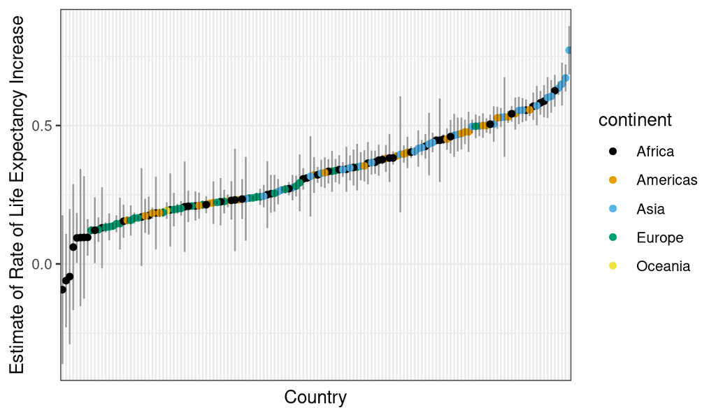

  ```r
  library(ggthemes)
  model_summary_df %>%
    filter(term == "year") %>%
    mutate(country = fct_reorder(country, estimate)) %>%
    ggplot(aes(x = country, y = estimate, color = continent)) +
    geom_point() +
    geom_segment(aes(x = country, xend = country, y = conf.low, yend = conf.high),
                 color = "black",
                 alpha = 1/3) +
    ylab("Estimate of Rate of Life Expectancy Increase") +
    xlab("Country") +
    theme(axis.text.x = element_blank(),
          axis.ticks.x = element_blank()) +
    scale_color_colorblind()
  ```

- You can check all of the models’ qualities by looking at the residuals

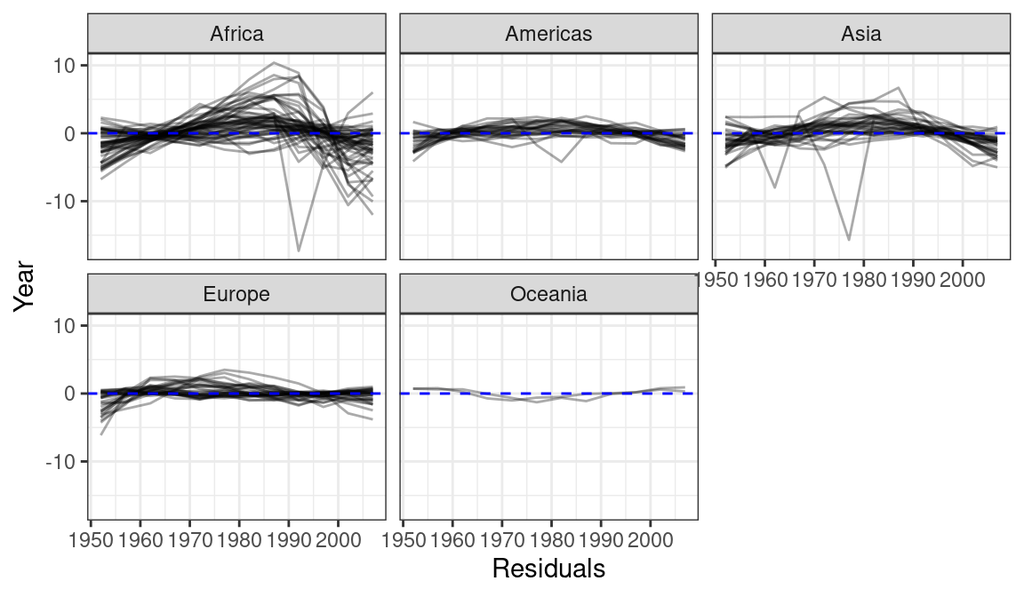

  ```r
  unnest(nested_gap_df, augmentout) ->
    augment_df

  augment_df %>%
    ggplot(aes(x = year, y = .resid, group = country)) +
    geom_line(alpha = 1/3) +
    facet_wrap(.~continent) +
    geom_hline(yintercept = 0, lty = 2, col = "blue") +
    xlab("Residuals") +
    ylab("Year")
  ```

- Above, we see there is a lot of curvature we are not accounting for.
- **Exercise**: Unnest the `tidy()` output from the linear model fit of log-population on year. Which countries have seen the greatest increase in population? Have any seen a decline?

# `mtcars` exercise

Recall how we used the `split()` function in the iterators worksheet on the `mtcars` dataset to get the regression coefficient estimates of a regression of `mpg` on `wt`.

```r
data("mtcars")
mtcars %>%
  split(.$cyl) %>%
  map(~lm(mpg ~ wt, data = .)) %>%
  map(~tidy(.)) %>%
  map_dbl(~.$estimate[2])
```

```
##      4      6      8
## -5.647 -2.780 -2.192
```

Redo this exercise using the `nest()`-`map()`-`unnest()` workflow we just went through.